# BA_Time Series3_Prediction_ Naive&Seasonal_Forecast

CHAPTER 16 Handling Time Series ---- describe the context of business time series forecasting and introduce the main approaches in particular, -----regression based forecasting and smoothing-based methods. ---- focus is on forecasting future values of a single time series.

These are meant as an introduction to the general forecasting approach and methods. --study a time series in terms of four components (level, trend, seasonality, and noise) --present methods for visualizing the different components and for exploring time series data. --discuss data partitioning, creating training and validation sets (performed differently from cross-sectional data partitioning).

CROSS SECTIIONAL DATA- time is not a factor, in the sense that it is not treated differently from other variables, and where the sequence of measurements over time does not matter.

Python-- use pandas for data handling and matplotlib for visualization. Models are built using statsmodels. NB:**kwargs are Extra arguments that are used to set model properties when using the formula interface.

Forecasting a single time series Vs multiple time series

The advantage of single-series forecasting is its simplicity. The disadvantage is that it does not take into account possible relationships between series.

16.2 Descriptive vs. Predictive Modeling As with cross-sectional data, modeling time series data is done for either descriptive or predictive purposes. --In descriptive modeling, or time series analysis, a time series is modeled to determine its components in terms of seasonal patterns, trends, relation to external factors, etc. --These can then be used for decision-making and policy formulation.

--In contrast, time series forecasting uses the information in a time series to forecast future values of that series. The difference between the goals of time series analysis and time series forecasting leads to differences in the type of methods used and in the modeling process itself.

--The focus here is on time series forecasting, where the goal is to predict future values of a time series. For information on time series analysis, see Chatfield (2003).

16.4 Time Series Components In forecasting methods, it is customary to dissect a time series into four components: level, trend, seasonality, and noise.

The first three components are assumed to be invisible, as they characterize the underlying series, which we only observe with added noise.

Level describes the average value of the series, trend is the change in the series from one period to the next, and seasonality describes a short-term cyclical behavior of the series which can be observed several times within the given series.

Finally, noise is the random variation that results from measurement error or other causes not accounted for. It is always present in a time series to some degree.

Don’t get confused by the standard conversational meaning of ”season” (winter, spring, etc.). The statistical meaning of ”season” refers to any time period that repeats itself in cycles within the larger time series.

Also, note that the term ”period” in forecasting means simply a span of time

In order to identify the components of a time series, the first step is to examine a time plot.

A time plot is a line chart of the series values over time, with temporal labels (e.g., calendar date) on the horizontal axis.

Example: Ridership on Amtrak Trains Amtrak, a US railway company, routinely collects data on ridership. Focus on forecasting future ridership using the series of monthly ridership between January 1991 and March 2004. These data are publicly available at www.forecastingprinciples.com. A time plot for the monthly Amtrak ridership series is to be plotted(values are in thousands of riders)

```python
import pandas as pd
import matplotlib.pylab as plt
import statsmodels.formula.api as sm
from statsmodels.tsa import tsatools
#from dmba import regressionSummary;
```

code for creating a time series plot

```python
#Amtrak_df = pd.read_csv('https://github.com/karlarao/forecast_examples/raw/master/Amtrak%20data.csv')
```

```python
Amtrak_df = pd.read_csv('E:/2020/BA/datasets/Amtrak.csv')
```

```python
Amtrak_df.head(3)
```

|  | Month | Ridership |
| --- | --- | --- |
| 0 | 01/01/1991 | 1708.917 |
| 1 | 01/02/1991 | 1620.586 |
| 2 | 01/03/1991 | 1972.715 |

```python
Amtrak_df.columns
```

```
Index(['Month', 'Ridership'], dtype='object')
```

```python
type(Amtrak_df.Month)
```

```
pandas.core.series.Series
```

```python
#checking
Amtrak_df.Month[1] - Amtrak_df.Month[0]
```

```
---------------------------------------------------------------------------
TypeError                                 Traceback (most recent call last)
<ipython-input-7-40f4c8633db3> in <module>
      1 #checking
----> 2 Amtrak_df.Month[1] - Amtrak_df.Month[0]

TypeError: unsupported operand type(s) for -: 'str' and 'str'
```

```python
Amtrak_df.Month.dtype
```

```
dtype('O')
```

```python
# convert the date information to a datetime object
Amtrak_df['Date'] = pd.to_datetime(Amtrak_df.Month, format='%d/%m/%Y')
```

```python
Amtrak_df.head(2)
```

|  | Month | Ridership | Date |
| --- | --- | --- | --- |
| 0 | 01/01/1991 | 1708.917 | 1991-01-01 |
| 1 | 01/02/1991 | 1620.586 | 1991-02-01 |

```python
type(Amtrak_df.Date)
```

```
pandas.core.series.Series
```

```python
Amtrak_df.Date[1] - Amtrak_df.Date[0]
```

```
Timedelta('31 days 00:00:00')
```

```python
#Amtrak_df.Ridership.values
```

```python
# convert dataframe column to series (name is used to label the data)
ridership_ts = pd.Series(Amtrak_df.Ridership.values, index=Amtrak_df.Date, name='Ridership')
ridership_ts.head(3)
```

```
Date
1991-01-01    1708.917
1991-02-01    1620.586
1991-03-01    1972.715
Name: Ridership, dtype: float64
```

```python
ridership_ts[1:5]
```

```
Date
1991-02-01    1620.586
1991-03-01    1972.715
1991-04-01    1811.665
1991-05-01    1974.964
Name: Ridership, dtype: float64
```

```python
ridership_ts.index
```

```
DatetimeIndex(['1991-01-01', '1991-02-01', '1991-03-01', '1991-04-01',
               '1991-05-01', '1991-06-01', '1991-07-01', '1991-08-01',
               '1991-09-01', '1991-10-01',
               ...
               '2003-06-01', '2003-07-01', '2003-08-01', '2003-09-01',
               '2003-10-01', '2003-11-01', '2003-12-01', '2004-01-01',
               '2004-02-01', '2004-03-01'],
              dtype='datetime64[ns]', name='Date', length=159, freq=None)
```

```
(1300, 2300)
```

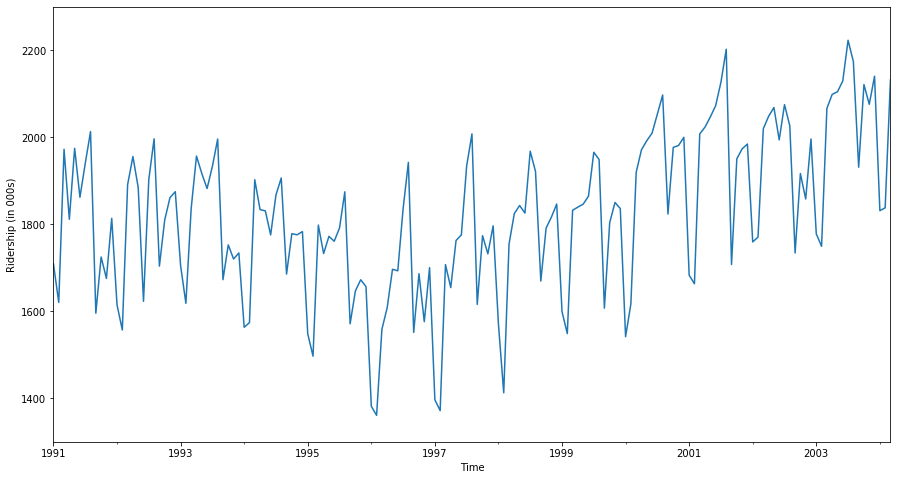

```python
# plot the series
ax = ridership_ts.plot(figsize=(15,8))
ax.set_xlabel('Time')
ax.set_ylabel('Ridership (in 000s)')
ax.set_ylim(1300, 2300)
```

Looking at the time plot reveals the nature of the series components:

--the overall level is around 1,800,000 passengers per month. --A slight U-shaped trend is discernible during this period, with pronounced annual seasonality, with peak travel during summer (July and August).

A second step in visualizing a time series is to examine it more carefully. A few tools are useful:

#### Zoom in:

```
Zooming in to a shorter period within the series can reveal patterns that are hidden when viewing the entire series.
This is especially important when the time series is long.
```

#### Change scale of series:

```
In order to better identify the shape of a trend, it is useful to change the scale of the series.
One option:check for an exponential trend - change the vertical scale to a logarithmic scale (use ax.set_yscale(‘log’)).
If the trend on the new scale appears more linear, then the trend in the original series is closer to an exponential
trend.
```

#### Add trend lines:

```
For better discerning the shape of the trend add a trend line. By trying different trendlines, one can see what type of trend (e.g.,
linear, exponential, quadratic) best approximates the data.
```

#### Suppress seasonality:

```
It is often easier to see trends in the data when seasonality is suppressed.
Suppressing seasonality patterns can be done by plotting the series at a cruder time scale
(e.g., aggregating monthly data into years) or creating separate time plots for each season (e.g., separate lines for each day of week).
Another popular option is to use moving average charts.
```

Plots that enhance the different components of the time series. (a) Zoom-in to 3 years of data. (b) Original series with overlaid quadratic trendline

```python
# create short time series from 1997 to 1999 using a slice
ridership_ts_3yrs = ridership_ts['1997':'1999']
type(ridership_ts_3yrs)
```

```
pandas.core.series.Series
```

```python
ridership_ts_3yrs[1:10]
```

```
Date
1997-02-01    1371.690
1997-03-01    1707.522
1997-04-01    1654.604
1997-05-01    1762.903
1997-06-01    1775.800
1997-07-01    1934.219
1997-08-01    2008.055
1997-09-01    1615.924
1997-10-01    1773.910
Name: Ridership, dtype: float64
```

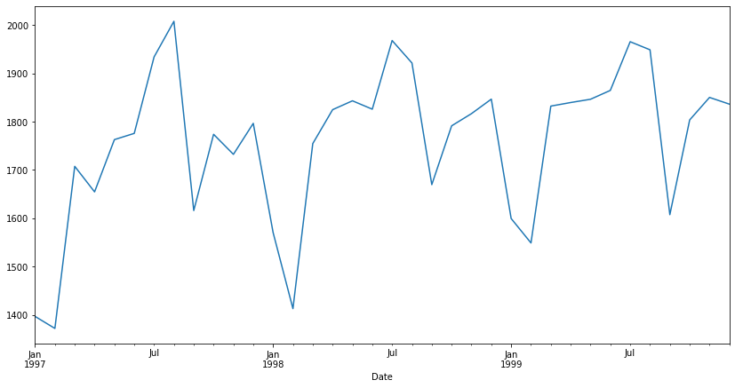

```python
%matplotlib inline
from matplotlib import pyplot
ridership_ts_3yrs.plot(figsize=(14,7))
pyplot.show;
```

```python
# create a data frame with additional predictors from time series
# the following command adds a constant term, a trend term and a quadratic trend term
ridership_df = tsatools.add_trend(ridership_ts, trend='ctt');
```

## Parameters

```
x : array_like
    Original array of data.
trend : str {'n', 'c', 't', 'ct', 'ctt'}
    The trend to add.

    * 'n' add no trend.
    * 'c' add constant only.
    * 't' add trend only.
    * 'ct' add constant and linear trend.
    * 'ctt' add constant and linear and quadratic trend.
```

```python
ridership_df.head(5)
```

| Date | Ridership | const | trend | trend_squared |
| --- | --- | --- | --- | --- |
| 1991-01-01 | 1708.917 | 1.0 | 1.0 | 1.0 |
| 1991-02-01 | 1620.586 | 1.0 | 2.0 | 4.0 |
| 1991-03-01 | 1972.715 | 1.0 | 3.0 | 9.0 |
| 1991-04-01 | 1811.665 | 1.0 | 4.0 | 16.0 |
| 1991-05-01 | 1974.964 | 1.0 | 5.0 | 25.0 |

```python
# fit a linear regression model to the time series with only trend
ridership_lm = sm.ols(formula='Ridership ~ trend',data=ridership_df).fit()
```

```python
# or fit a linear regression model to the time series with trend and trend squared
ridership_lm = sm.ols(formula='Ridership ~ trend + trend_squared',data=ridership_df).fit()
```

```python
sm.ols?
```

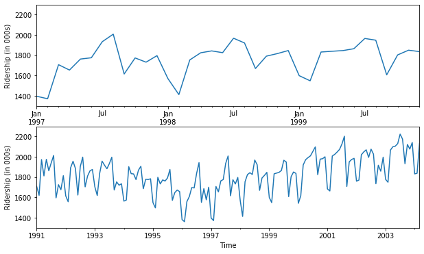

```python
# shorter and longer time series
# draw 2 subplots
fig, axes = plt.subplots(nrows=2, ncols=1, figsize=(10,6))
ridership_ts_3yrs.plot(ax=axes[0])
ridership_ts.plot(ax=axes[1])
for ax in axes:
    ax.set_xlabel('Time')
    ax.set_ylabel('Ridership (in 000s)')
    ax.set_ylim(1300, 2300)
#ridership_lm.predict(ridership_df).plot(ax=axes[1])
plt.show()
```

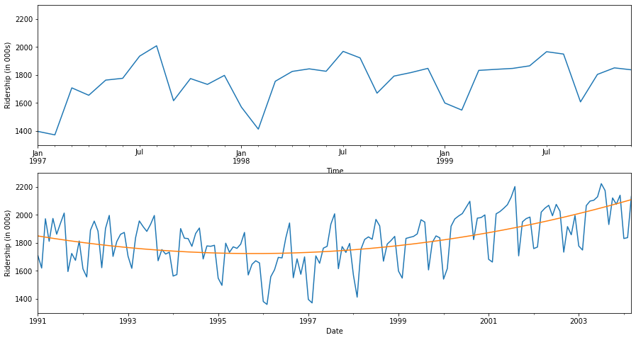

```python
# shorter and longer time series
# draw 2 subplots
fig, axes = plt.subplots(nrows=2, ncols=1, figsize=(15,8))
ridership_ts_3yrs.plot(ax=axes[0])
ridership_ts.plot(ax=axes[1])
for ax in axes:
    ax.set_xlabel('Time')
    ax.set_ylabel('Ridership (in 000s)')
    ax.set_ylim(1300, 2300)
ridership_lm.predict(ridership_df).plot(ax=axes[1])
plt.show()
```

```python
+++++++++++++++++
```

```python
Some forecasting methods directly model these components by making assumptions about their structure.
For example, a popular assumption about trend is that it is linear or exponential over the given time period or part of it.

Another common assumption is about the noise structure: many statistical methods assume that the noise follows a normal
distribution.

The advantage of methods that rely on such assumptions is that when the assumptions are reasonably met, the resulting forecasts will be more robust and the
models more understandable.

Other forecasting methods, which are data-adaptive, make fewer assumptions about the structure of these components,
and instead try to estimate them only from the data. Data-adaptive methods are advantageous when such assumptions are
likely to be violated, or when the structure of the time series changes over time.
```

```python
Fig above: (a) Zoom-in to 3 years of data. (b) Original series with overlaid quadratic trendline
```

## Data-Partitioning and Performance Evaluation

```python
As in the case of cross-sectional data, in order to avoid overfitting and to be able to assess
the predictive performance of the model on new data, first partition the data into a
training set and a validation set (and perhaps an additional test set).

However, there is one important difference between data partitioning in cross-sectional and time series
data. In cross-sectional data, the partitioning is usually done randomly, with a random set of records designated
as training data and the remainder as validation data.

However, in time series, a random partition would create two time series with “holes.” Nearly all
standard forecasting methods cannot handle time series with missing values.

Therefore, we partition a time series into training and validation sets differently. The series is
trimmed into two periods; the earlier period is set as the training data and the later period
as the validation data.

Methods are then trained on the earlier training period, and their predictive performance assessed on the later
validation period.

Evaluation measures typically use the same metrics used in cross-sectional evaluation with
MAE, MAPE, and RMSE being the most popular metrics in practice.

In evaluating and comparing forecasting methods, another important tool is visualization: examining time
plots of the actual and predicted series can shed light on performance and hint toward
possible improvements.
```

```python
Benchmark Performance: Naive Forecasts
While it is tempting to apply “sophisticated” forecasting methods, we must evaluate their
value added compared to a very simple approach: the naive forecast.

A naive forecast is simply the most recent value of the series. In other words, at time t, our forecast for any
future period t + k is simply the value of the series at time t.

It is important to benchmark against results from a naive-forecasting approach.

When a time series has seasonality, a seasonal naive forecast can be generated. It is
simply the last similar value in the season.

For example, to forecast April 2001 for Amtrak ridership, we use the ridership from the most recent April,i.e., April 2000.
Similarly, to forecast April 2002, we also use April 2000 ridership.

In Figure, we see naive (horizontal line) and seasonal naive forecasts, as well as actual values (dotted line), in a
3-year validation set from April 2001 to March 2004.
```

```python
nValid = 36
```

```python
nTrain = len(ridership_ts) - nValid
```

```python
len(ridership_ts)
print(nTrain)
```

```
123
```

```python
ridership_ts[1:6]
```

```
Date
1991-02-01    1620.586
1991-03-01    1972.715
1991-04-01    1811.665
1991-05-01    1974.964
1991-06-01    1862.356
Name: Ridership, dtype: float64
```

```python
# partition the data
train_ts = ridership_ts[:nTrain]
valid_ts = ridership_ts[nTrain:]
```

```python
train_ts[122]
```

```
2007.9279999999999
```

```python
#ridership_ts[nTrain:]
```

```python
valid_ts = ridership_ts[nTrain:]
#valid_ts
```

```python
train_ts[-1]
```

```
2007.9279999999999
```

```python
index=valid_ts.index
type(index)
```

```
pandas.core.indexes.datetimes.DatetimeIndex
```

### Generate Naive Forecast

```python
# naive forecast
naive_pred = pd.Series(train_ts[-1], index=valid_ts.index)
#naive_pred # 2001-03-01    2007.928  constant taken
```

### Generate Seasonal Forecast

```python
#12 months prior in the training data
last_season = train_ts[-12:]
last_season
```

```
Date
2000-04-01    1971.493
2000-05-01    1992.301
2000-06-01    2009.763
2000-07-01    2053.996
2000-08-01    2097.471
2000-09-01    1823.706
2000-10-01    1976.997
2000-11-01    1981.408
2000-12-01    2000.153
2001-01-01    1683.148
2001-02-01    1663.404
2001-03-01    2007.928
Name: Ridership, dtype: float64
```

```python
# generate the seasonal naive forecast
seasonal_pred = pd.Series(pd.concat([last_season]*3) [:len(valid_ts)].values,index=valid_ts.index)
```

```python
[last_season]*3
```

```
[Date
 2000-04-01    1971.493
 2000-05-01    1992.301
 2000-06-01    2009.763
 2000-07-01    2053.996
 2000-08-01    2097.471
 2000-09-01    1823.706
 2000-10-01    1976.997
 2000-11-01    1981.408
 2000-12-01    2000.153
 2001-01-01    1683.148
 2001-02-01    1663.404
 2001-03-01    2007.928
 Name: Ridership, dtype: float64, Date
 2000-04-01    1971.493
 2000-05-01    1992.301
 2000-06-01    2009.763
 2000-07-01    2053.996
 2000-08-01    2097.471
 2000-09-01    1823.706
 2000-10-01    1976.997
 2000-11-01    1981.408
 2000-12-01    2000.153
 2001-01-01    1683.148
 2001-02-01    1663.404
 2001-03-01    2007.928
 Name: Ridership, dtype: float64, Date
 2000-04-01    1971.493
 2000-05-01    1992.301
 2000-06-01    2009.763
 2000-07-01    2053.996
 2000-08-01    2097.471
 2000-09-01    1823.706
 2000-10-01    1976.997
 2000-11-01    1981.408
 2000-12-01    2000.153
 2001-01-01    1683.148
 2001-02-01    1663.404
 2001-03-01    2007.928
 Name: Ridership, dtype: float64]
```

```python
seasonal_pred
```

```
Date
2001-04-01    1971.493
2001-05-01    1992.301
2001-06-01    2009.763
2001-07-01    2053.996
2001-08-01    2097.471
2001-09-01    1823.706
2001-10-01    1976.997
2001-11-01    1981.408
2001-12-01    2000.153
2002-01-01    1683.148
2002-02-01    1663.404
2002-03-01    2007.928
2002-04-01    1971.493
2002-05-01    1992.301
2002-06-01    2009.763
2002-07-01    2053.996
2002-08-01    2097.471
2002-09-01    1823.706
2002-10-01    1976.997
2002-11-01    1981.408
2002-12-01    2000.153
2003-01-01    1683.148
2003-02-01    1663.404
2003-03-01    2007.928
2003-04-01    1971.493
2003-05-01    1992.301
2003-06-01    2009.763
2003-07-01    2053.996
2003-08-01    2097.471
2003-09-01    1823.706
2003-10-01    1976.997
2003-11-01    1981.408
2003-12-01    2000.153
2004-01-01    1683.148
2004-02-01    1663.404
2004-03-01    2007.928
dtype: float64
```

```python
# plot forecasts and actual in the training and validation sets
```

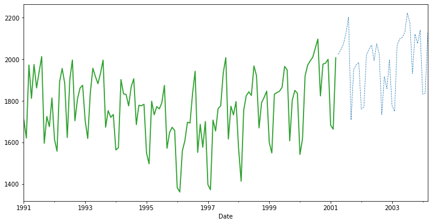

```python
ax = train_ts.plot(color='C2', linewidth=1.75, figsize=(12,6))
valid_ts.plot(ax=ax, color='C0', linestyle='dashed', linewidth=0.75)
```

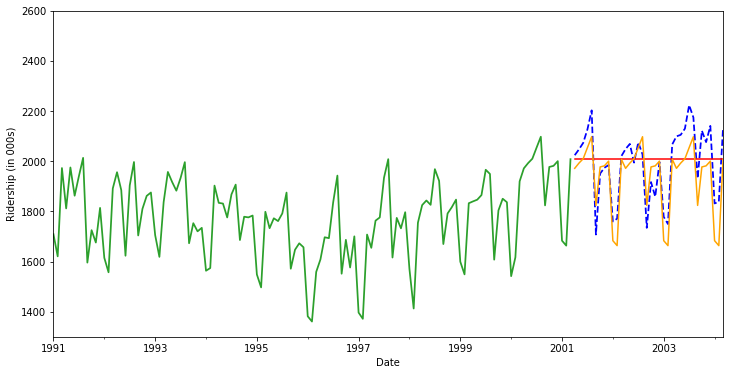

```python
ax = train_ts.plot(color='C2', linewidth=1.75, figsize=(12,6))
valid_ts.plot(ax=ax, color='blue', linestyle='dashed', linewidth=1.75)
ax.set_xlim('1990', '2006-6')
ax.set_ylim(1300, 2600)
ax.set_xlabel('Time')
ax.set_ylabel('Ridership (in 000s)')
naive_pred.plot(ax=ax, color='red')
seasonal_pred.plot(ax=ax, color='orange')
```

```python
from dmba import regressionSummary;
```

```
no display found. Using non-interactive Agg backend
```

```python
regressionSummary(valid_ts, naive_pred)
```

```
Regression statistics

                      Mean Error (ME) : -14.7177
       Root Mean Squared Error (RMSE) : 142.7551
            Mean Absolute Error (MAE) : 115.9234
          Mean Percentage Error (MPE) : -1.2750
Mean Absolute Percentage Error (MAPE) : 6.0214
```

```python
regressionSummary(valid_ts, seasonal_pred)
```

```
Regression statistics

                      Mean Error (ME) : 54.7296
       Root Mean Squared Error (RMSE) : 95.6243
            Mean Absolute Error (MAE) : 84.0941
          Mean Percentage Error (MPE) : 2.6528
Mean Absolute Percentage Error (MAPE) : 4.2477
```

### Generating Future Forecasts

Another important difference between cross-sectional and time-series partitioning occurs when creating the actual forecasts. Before attempting to forecast future values of the series, the training and validation sets are recombined into one long series, and the chosen method/model is rerun on the complete data. This final model is then used to forecast future values. The three advantages in recombining are:

1. The validation set, which is the most recent period, usually contains the most valuable information in terms of being the closest in time to the forecast period;
2. With more data (the complete time series compared to only the training set), some models can be estimated more accurately;
3. If only the training set is used to generate forecasts, then it will require forecasting farther into the future (e.g., if the validation set contains four time points, forecasting the next period will require a five-step-ahead forecast from the training set).

```python
Next Regression Based Forecasting
```